# Práctica 2: Limpieza y validación de los datos

### 5.3.2 diferencias en la proporcion de mujeres con obesidad en pacientes diabeticas y no diabeticas

A continuación vamos a esudiar si existe alguna diferencia significativa en la proporción de pacientes con obesidad (BMI >= 30) en la muestra poblacional de pacientes diabéticas y no diabéticas.

La pregunta de investigación que nos planteamos es la siguiente:

**¿Existe diferencia significativa en la proporción de mujeres con BMI >= 30 en pacientes diabéticas o no diabéticas?**

Definimos la hipótesis nula y alternativa:

- $H_0$: La proporción de pacientes con BMI igual o superior a 30 es la misma en pacientes diabéticas y no diabéticas.

$$p_{ND} = p_D$$
* $H_1$: La proporción de pacientes con BMI igual o superior a 30 es diferente en pacientes diabéticas y no diabéticas.

$$p_{ND} ≠ p_D$$

Especificaciones del contraste de hipótesis:

- Contraste de dos muestras no relacionadas sobre la proporción
- En base al Teorema del Límite Central, asumimos normalidad en muestras grandes (generalmente superior a 30 observaciones)
- Aplicamos un test paramétrico bilateral.

Aplicamos el contraste:

```r
n_no_diab = length(df_no_diab$BMI)
n_diab = length(df_diab$BMI)

p_no_diab = sum(df_no_diab$BMI >= 30)/n_no_diab
p_diab = sum(df_diab$BMI >= 30)/n_diab

success = c(n_no_diab * p_no_diab, n_diab * p_diab)
nn = c(n_no_diab, n_diab)

prop.test(success, nn, alternative = "two.sided", correct = FALSE, conf.level = 0.95)
```

```
##
##  2-sample test for equality of proportions without continuity
##  correction
##
## data:  success out of nn
## X-squared = 71.32, df = 1, p-value < 2.2e-16
## alternative hypothesis: two.sided
## 95 percent confidence interval:
##  0.2474302 0.3748982
## sample estimates:
##    prop 1    prop 2
## 0.8171642 0.5060000
```

En este caso, obtenemos un p-valor muy pequeño, por lo que podemos rechazar la hipótesis nula de igualdad de proporciones y concluir que la proporción de pacientes con obesidad es diferente en pacientes no diabéticas y diabéticas.

### 5.3.4. Correlación entre variables descriptivas

Vamos a realizar un análisis de correlación entre las variables cuantitativas de las que disponemos, con el objetivo de comprobar si sus distribuciones están relacionadas:

```r
library(PerformanceAnalytics)
```

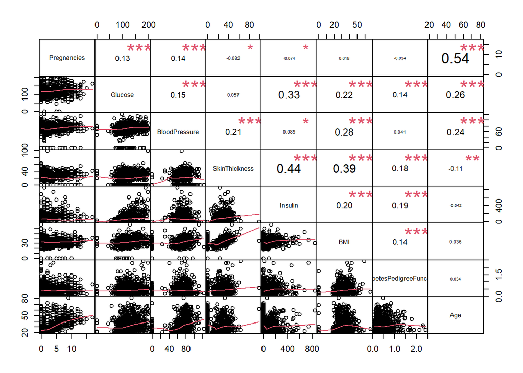

```r
#data.frame(round(cor(df[,list_var]), 2))
chart.Correlation(df[,list_var], histogram = F, pch = 19)
```

Con esta gráfica observamos que no existe un nivel de correlación excesivamente alto en nuestro conjunto de variables. Observamos que Pregnancies y Age tienen un coeficiente de correlación de 0.54, lo cual tiene cierto sentido debido a que a mas edad, mas posibilidad de haber tenido mas hijos. También se percibe un coeficiente de correlación del 0.44 entre SkinThickness e Insulin.

### 5.3.5. Modelo de regresión logística

Vamos a construir un modelo de regresión logística a partir de nuestro conjunto de datos, que sea capaz de identificar una persona con diabetes o no en base a las variables del conjunto de datos. Esto nos ayudará también a ver que variables influyen mas en la probabilidad de padecer diabetes.

```r
model_glm = glm(as.factor(Outcome) ~ ., data = df, family=binomial)

summary(model_glm)
```

```
##
## Call:
## glm(formula = as.factor(Outcome) ~ ., family = binomial, data = df)
##
## Deviance Residuals:
##     Min       1Q   Median       3Q      Max
## -2.5566  -0.7274  -0.4159   0.7267   2.9297
##
## Coefficients:
##                            Estimate Std. Error z value Pr(>|z|)
## (Intercept)              -8.4046964  0.7166359 -11.728  < 2e-16 ***
## Pregnancies               0.1231823  0.0320776   3.840 0.000123 ***
## Glucose                   0.0351637  0.0037087   9.481  < 2e-16 ***
## BloodPressure            -0.0132955  0.0052336  -2.540 0.011072 *
## SkinThickness             0.0006190  0.0068994   0.090 0.928515
## Insulin                  -0.0011917  0.0009012  -1.322 0.186065
## BMI                       0.0897010  0.0150876   5.945 2.76e-09 ***
## DiabetesPedigreeFunction  0.9451797  0.2991475   3.160 0.001580 **
## Age                       0.0148690  0.0093348   1.593 0.111192
## ---
## Signif. codes:  0 '***' 0.001 '**' 0.01 '*' 0.05 '.' 0.1 ' ' 1
##
## (Dispersion parameter for binomial family taken to be 1)
##
##     Null deviance: 993.48  on 767  degrees of freedom
## Residual deviance: 723.45  on 759  degrees of freedom
## AIC: 741.45
##
## Number of Fisher Scoring iterations: 5
```

Observando los resultados del modelo, vemos que nos dice que las variables mas influyentes en el cálculo de la probabilidad de tener o no diabetes son Pregnancies, Glucose, BMI, DiabetesPedigreeFunction y BloodPressure. Observando sus coeficientes vemos que estas variables, en su mayoría, tienen un efecto positivo en la probabilidad de padecer diabetes. Esto quiere decir que la posibilidad de tener diabetes aumenta con valores mas elevados en estas variables. La única variable de las mas influyentes que tiene un coeficiente negativo es BloodPressure, lo cual nos dice que un mayor valor en esta variable inplica una reducción en la posibilidad de padecer diabetes.

Construimos otro modelo empleando únicamente las variables influyentes:

```r
model_glm2 = glm(as.factor(Outcome) ~ Pregnancies + Glucose + BMI + DiabetesPedigreeFunction + BloodPressure, data = df, family=binomial)

summary(model_glm2)
```

```
##
## Call:
## glm(formula = as.factor(Outcome) ~ Pregnancies + Glucose + BMI +
##     DiabetesPedigreeFunction + BloodPressure, family = binomial,
##     data = df)
##
## Deviance Residuals:
##     Min       1Q   Median       3Q      Max
## -2.7931  -0.7362  -0.4188   0.7251   2.9555
##
## Coefficients:
##                           Estimate Std. Error z value Pr(>|z|)
## (Intercept)              -7.954952   0.675823 -11.771  < 2e-16 ***
## Pregnancies               0.153492   0.027835   5.514  3.5e-08 ***
## Glucose                   0.034658   0.003394  10.213  < 2e-16 ***
## BMI                       0.084832   0.014125   6.006  1.9e-09 ***
## DiabetesPedigreeFunction  0.910628   0.294027   3.097  0.00195 **
## BloodPressure            -0.012007   0.005031  -2.387  0.01700 *
## ---
## Signif. codes:  0 '***' 0.001 '**' 0.01 '*' 0.05 '.' 0.1 ' ' 1
##
## (Dispersion parameter for binomial family taken to be 1)
##
##     Null deviance: 993.48  on 767  degrees of freedom
## Residual deviance: 728.56  on 762  degrees of freedom
## AIC: 740.56
##
## Number of Fisher Scoring iterations: 5
```

Comparando ambos modelos, vemos que el segundo toma un valor del AIC (Criterio de información de AKAIKE) inferior. Este parámetro nos indica un modelo de mayor calidad conforme disminuye su valor, por lo que este segundo modelo que emplea únicamente las variables consideradas significativas se ajusta mejor a los datos que el anterior, que emplea todas.

# 6. Conclusiones y resolución del problema

Con estos resultados podemos construir un sistema que permita identificar pacientes diabéticas en base a la información que tengamos de estas variables. Este modelo de regresión logística nos sirve de ejemplo de aplicación de una herramienta que clasifique a una paciente observada como diabética o no diabética.

```r
newdata = data.frame(
    Pregnancies = 5,
    Glucose = 115,
    BloodPressure = 74,
    SkinThickness = 0,
    Insulin = 0,
    BMI = 25.6,
    DiabetesPedigreeFunction = 0.201,
    Age = 30
)

prediction = ifelse(predict(model_glm2, newdata) <0.5, 0, 1)

prediction
```

```
## 1
## 0
```